# Assignment for Research Assistant Position at GSME

## Author: Fatemeh Abbasian-Abyaneh

```python
# Import required libraries
import matplotlib.pyplot as plt
from pdfminer.high_level import extract_text
import csv
import os
import pandas as pd
import numpy as np
from collections import Counter
import string
from prettytable import PrettyTable
import re
import nltk
from nltk.tokenize import word_tokenize
from nltk.corpus import stopwords
from nltk.stem import WordNetLemmatizer
from nltk.util import ngrams
from nltk.corpus import wordnet
from nltk import pos_tag
from pdfminer.high_level import extract_text
from textblob import TextBlob
from sklearn.feature_extraction.text import CountVectorizer
from sklearn.decomposition import LatentDirichletAllocation
from sklearn.feature_extraction.text import CountVectorizer
```

```python
# Download necessary NLTK data
nltk.download('punkt')
nltk.download('stopwords')
nltk.download('wordnet')
nltk.download('averaged_perceptron_tagger')
```

```
True
```

### **Introduction**

The Federal Open Market Committee (FOMC) statements are critical documents that reflect the U.S. Federal Reserve's views on economic conditions and their monetary policy decisions. These statements are analyzed by economists, financial analysts, and policymakers to gauge the economic outlook and anticipate future policy actions. In this project, the goal is to develop a quantitative measure that captures the sentiment (optimism or pessimism) and the policy stance (expansionary or contractionary) of FOMC statements issued between December 2015 and July 2024.

### **Objective**

The primary objectives of this analysis are:

1. **Sentiment Analysis**: To create a continuous measure ranging from -1 to 1 that quantifies the sentiment of each FOMC statement, where -1 represents extreme pessimism and 1 represents extreme optimism.
2. **Policy Stance Analysis**: To develop a similar measure that quantifies the policy stance of each FOMC statement, where -1 represents a strongly contractionary stance and 1 represents a strongly expansionary stance.

These measures will be generated using unsupervised machine learning techniques, specifically **Latent Dirichlet Allocation (LDA)**, a topic modeling approach. The aim is to understand the underlying themes in the FOMC statements and to use these themes to inform the sentiment and policy stance scores.

### **Methodology**

#### **1. Data Collection and Preprocessing**

The data consists of FOMC statements available on the Federal Reserve’s website. These documents have been collected, and the text has been extracted and cleaned for further analysis. The preprocessing steps involve:

- **Text Extraction**: Extracting the text from PDF files and converting them to a machine-readable format.
- **Text Cleaning**: Removing unnecessary characters, stopwords, and performing tokenization to prepare the text for analysis.

#### **2. Topic Modeling with LDA**

**Latent Dirichlet Allocation (LDA)** is a generative probabilistic model that is used to uncover hidden topics within a collection of documents. Here’s how LDA contributes to the project:

- **Topic Identification**:
  - LDA will be applied to the FOMC statements to identify underlying topics. These topics might include economic growth, inflation, labor market conditions, or monetary policy actions.
  - Each topic is represented by a distribution of words, and each document (FOMC statement) is represented by a distribution of topics. This allows us to understand the mix of topics discussed in each statement.
- **Assigning Sentiment and Policy Scores**:
  - Once topics are identified, they will be manually analyzed to assign sentiment and policy scores. For example, a topic that frequently includes words related to "growth," "expansion," and "improvement" might be associated with a positive sentiment score, while a topic focused on "recession," "decline," or "unemployment" might be associated with a negative sentiment score.
  - Similarly, topics that discuss actions such as "rate hike," "tightening," or "contraction" would be assigned a contractionary policy score, while topics focusing on "easing," "lowering rates," or "stimulus" would be assigned an expansionary policy score.

#### **3. Calculating Document-Level Scores**

For each FOMC statement:

- **Weighted Sentiment Score**: The sentiment score for each document will be calculated by taking a weighted average of the sentiment scores of the topics within the document, with weights corresponding to the proportion of each topic in the document.
- **Weighted Policy Score**: Similarly, the policy stance score will be calculated using the weighted average of the policy scores assigned to the topics.

This approach ensures that each document’s sentiment and policy score reflects the relative importance of different topics discussed in the statement.

#### **4. Analysis and Validation**

- **Time-Series Analysis**: By applying LDA across multiple FOMC statements over time, we can observe how the distribution of topics—and by extension, the sentiment and policy stance—evolves. This can provide insights into how the Federal Reserve's outlook and policy priorities have changed in response to economic conditions.
- **Correlation with Economic Indicators**: The sentiment and policy measures derived from the FOMC statements can be correlated with real-world economic indicators (such as GDP growth, inflation rates, and unemployment) to validate their relevance and accuracy.

### **Data Collection and Preprocessing**

The data collection and preprocessing phase is critical to ensure that the FOMC statements are in a suitable format for analysis. This section of the report details the steps taken to extract and clean the text from the PDF documents of FOMC statements.

#### **1. Text Extraction**

The FOMC statements are originally published in PDF format, which necessitates the extraction of text into a machine-readable format for analysis. To accomplish this, we utilized the `pdfminer.six` library, a robust tool for extracting text from PDFs.

```python
def extract_clean_text_from_pdf(pdf_path):
    # Extract text using pdfminer.six
    text = extract_text(pdf_path)

    # Perform text cleaning
    text = text.replace('\n', ' ').strip()  # Remove newlines and strip leading/trailing spaces
    text = ' '.join(text.split())  # Remove extra spaces

    return text
```

#### **2. Splitting the Text into Semantic and Policy Sections**

The FOMC statements typically follow a structured format where the initial sections discuss the state of the economy, including trends in inflation, employment, and other macroeconomic indicators. Later in the document, a section specifically titled **"Decisions Regarding Monetary Policy Implementation"** outlines the actions that the Federal Reserve plans to take. We can leverage this consistent structure to split the text effectively.

#### **Explanation of the Function:**

- **Split Keyword (`split_keyword = "Decisions Regarding Monetary Policy Implementation"`):**
  - The function begins by defining a split keyword, `"Decisions Regarding Monetary Policy Implementation"`. This phrase is used to identify the point in the text where the discussion shifts from economic conditions to the specific policy measures that the Federal Reserve plans to implement.
- **Splitting the Text (`re.split(f'({split_keyword})', text, maxsplit=1)`):**
  - The function uses the `re.split()` method from Python's `re` (regular expression) module to split the text at the first occurrence of the split keyword. The `maxsplit=1` parameter ensures that the text is only split into two parts, capturing everything before the keyword as the semantic section and everything after the keyword as the policy section.
  - The split returns a list `parts` where:
    - `parts[0]` contains the text before the split keyword (economic conditions).
    - `parts[1]` contains the split keyword itself.
    - `parts[2]` contains the text after the split keyword (monetary policy decisions).
- **Assigning Text Sections (`if len(parts) > 1:`):**
  - The function checks if the split was successful (i.e., if the keyword was found). If successful:
    - `semantic_text` is assigned the content before the split keyword.
    - `policy_text` is assigned the split keyword plus the content following it.
  - If the split keyword is not found (which is unlikely given the consistent structure of FOMC statements), the entire text is assigned to `semantic_text`, and `policy_text` is left empty.
- **Return Sections (`return semantic_text, policy_text`):**
  - The function returns two separate strings: `semantic_text` (containing the discussion on economic conditions) and `policy_text` (containing the monetary policy measures).

#### **Why This Step is Important:**

- **Focused Analysis**: Splitting the text allows for targeted analysis of different parts of the FOMC statements. The semantic section can be analyzed for sentiment regarding economic outlook, while the policy section can be examined to understand the nature of the monetary policy (whether expansionary or contractionary).
- **Accurate Topic Modeling**: By isolating the economic conditions from policy decisions, the subsequent topic modeling process can yield more accurate and meaningful results. Topics related to economic sentiment can be clearly distinguished from those related to policy actions.
- **Structured Data for LDA**: This step prepares the data in a structured manner, which is essential for applying Latent Dirichlet Allocation (LDA) or any other unsupervised learning technique. Each section can be treated as a separate document or part of the same document, depending on the desired analysis.

### **Next Steps:**

After splitting the text into semantic and policy sections, the next step involves further preprocessing such as tokenization, stopword removal, and potentially stemming or lemmatization, before applying LDA to uncover underlying topics and derive sentiment and policy stance measures. These processes will be detailed in subsequent sections of the report.

```python
def split_text(text):
    # Define the split keyword or phrase that identifies the start of the policy section
    split_keyword = "Decisions Regarding Monetary Policy Implementation"

    # Split the text at the first occurrence of the split keyword
    parts = re.split(f'({split_keyword})', text, maxsplit=1)

    if len(parts) > 1:
        semantic_text = parts[0].strip()
        policy_text = split_keyword + " " + parts[2].strip()
    else:
        # If the keyword isn't found, assign the whole text to semantic_text
        semantic_text = text
        policy_text = ""

    return semantic_text, policy_text
```

The `save_text_to_csv` function writes the provided text to a CSV file, adding a header labeled "Text" and saving the entire text as a single row. This ensures the text is stored in a structured, accessible format for further analysis.

```python
def save_text_to_csv(text, csv_path):
    # Write to CSV, each line can be a row in the CSV
    with open(csv_path, mode='w', newline='', encoding='utf-8') as file:
        writer = csv.writer(file)
        writer.writerow(["Text"])  # Header
        writer.writerow([text])  # Save all text in one row
```

### **Batch Processing of FOMC Statements**

To efficiently process multiple FOMC statement PDFs, the `process_pdfs_to_csv` function automates the workflow. It iterates through all PDF files in a specified directory, extracting and cleaning the text from each file. The text is then split into two sections: economic conditions (semantic) and monetary policy (policy). Each section is saved into separate CSV files, organizing the data for further analysis. This automated approach ensures consistency and scalability when handling large numbers of documents.

```python
def process_pdfs_to_csv(pdf_dir, output_dir):
    for filename in os.listdir(pdf_dir):
        if filename.endswith(".pdf"):
            pdf_path = os.path.join(pdf_dir, filename)
            base_filename = filename.replace('.pdf', '')

            # Extract and split the text
            clean_text = extract_clean_text_from_pdf(pdf_path)
            semantic_text, policy_text = split_text(clean_text)

            # Save the semantic text
            semantic_csv_path = os.path.join(output_dir, f"{base_filename}_semantic.csv")
            save_text_to_csv(semantic_text, semantic_csv_path)

            # Save the policy text
            if policy_text:
                policy_csv_path = os.path.join(output_dir, f"{base_filename}_policy.csv")
                save_text_to_csv(policy_text, policy_csv_path)

            print(f"Processed {filename} into {base_filename}_semantic.csv and {base_filename}_policy.csv")
```

```python
pdf_directory = 'C:/Users/fatem/Downloads/NLP/RATask/statements'  # Directory containing PDF files
output_directory = 'C:/Users/fatem/Downloads/NLP/RATask/statements'  # Directory to save CSV files
os.makedirs(output_directory, exist_ok=True)  # Ensure output directory exists

process_pdfs_to_csv(pdf_directory, output_directory)
```

```
Processed 2015_1.pdf into 2015_1_semantic.csv and 2015_1_policy.csv
Processed 2016_1.pdf into 2016_1_semantic.csv and 2016_1_policy.csv
Processed 2016_2.pdf into 2016_2_semantic.csv and 2016_2_policy.csv
Processed 2016_3.pdf into 2016_3_semantic.csv and 2016_3_policy.csv
Processed 2016_4.pdf into 2016_4_semantic.csv and 2016_4_policy.csv
Processed 2016_5.pdf into 2016_5_semantic.csv and 2016_5_policy.csv
Processed 2016_6.pdf into 2016_6_semantic.csv and 2016_6_policy.csv
Processed 2016_7.pdf into 2016_7_semantic.csv and 2016_7_policy.csv
Processed 2016_8.pdf into 2016_8_semantic.csv and 2016_8_policy.csv
Processed 2017_1.pdf into 2017_1_semantic.csv and 2017_1_policy.csv
Processed 2017_2.pdf into 2017_2_semantic.csv and 2017_2_policy.csv
Processed 2017_3.pdf into 2017_3_semantic.csv and 2017_3_policy.csv
Processed 2017_4.pdf into 2017_4_semantic.csv and 2017_4_policy.csv
Processed 2017_5.pdf into 2017_5_semantic.csv and 2017_5_policy.csv
Processed 2017_6.pdf into 2017_6_semantic.csv and 2017_6_policy.csv
Processed 2017_7.pdf into 2017_7_semantic.csv and 2017_7_policy.csv
Processed 2017_8.pdf into 2017_8_semantic.csv and 2017_8_policy.csv
Processed 2018_1.pdf into 2018_1_semantic.csv and 2018_1_policy.csv
Processed 2018_2.pdf into 2018_2_semantic.csv and 2018_2_policy.csv
Processed 2018_3.pdf into 2018_3_semantic.csv and 2018_3_policy.csv
Processed 2018_4.pdf into 2018_4_semantic.csv and 2018_4_policy.csv
Processed 2018_5.pdf into 2018_5_semantic.csv and 2018_5_policy.csv
Processed 2018_6.pdf into 2018_6_semantic.csv and 2018_6_policy.csv
Processed 2018_7.pdf into 2018_7_semantic.csv and 2018_7_policy.csv
Processed 2018_8.pdf into 2018_8_semantic.csv and 2018_8_policy.csv
Processed 2019_1.pdf into 2019_1_semantic.csv and 2019_1_policy.csv
Processed 2019_2.pdf into 2019_2_semantic.csv and 2019_2_policy.csv
Processed 2019_3.pdf into 2019_3_semantic.csv and 2019_3_policy.csv
Processed 2019_4.pdf into 2019_4_semantic.csv and 2019_4_policy.csv
Processed 2019_5.pdf into 2019_5_semantic.csv and 2019_5_policy.csv
Processed 2019_6.pdf into 2019_6_semantic.csv and 2019_6_policy.csv
Processed 2019_7.pdf into 2019_7_semantic.csv and 2019_7_policy.csv
Processed 2019_8.pdf into 2019_8_semantic.csv and 2019_8_policy.csv
Processed 2019_9.pdf into 2019_9_semantic.csv and 2019_9_policy.csv
Processed 2020_1.pdf into 2020_1_semantic.csv and 2020_1_policy.csv
Processed 2020_10.pdf into 2020_10_semantic.csv and 2020_10_policy.csv
Processed 2020_2.pdf into 2020_2_semantic.csv and 2020_2_policy.csv
Processed 2020_3.pdf into 2020_3_semantic.csv and 2020_3_policy.csv
Processed 2020_4.pdf into 2020_4_semantic.csv and 2020_4_policy.csv
Processed 2020_5.pdf into 2020_5_semantic.csv and 2020_5_policy.csv
```

[output cut: 18 more lines]

```
Processed 2022_7.pdf into 2022_7_semantic.csv and 2022_7_policy.csv
Processed 2022_8.pdf into 2022_8_semantic.csv and 2022_8_policy.csv
Processed 2023_1.pdf into 2023_1_semantic.csv and 2023_1_policy.csv
Processed 2023_2.pdf into 2023_2_semantic.csv and 2023_2_policy.csv
Processed 2023_3.pdf into 2023_3_semantic.csv and 2023_3_policy.csv
Processed 2023_4.pdf into 2023_4_semantic.csv and 2023_4_policy.csv
Processed 2023_5.pdf into 2023_5_semantic.csv and 2023_5_policy.csv
Processed 2023_6.pdf into 2023_6_semantic.csv and 2023_6_policy.csv
Processed 2023_7.pdf into 2023_7_semantic.csv and 2023_7_policy.csv
Processed 2023_8.pdf into 2023_8_semantic.csv and 2023_8_policy.csv
Processed 2024_1.pdf into 2024_1_semantic.csv and 2024_1_policy.csv
Processed 2024_2.pdf into 2024_2_semantic.csv and 2024_2_policy.csv
Processed 2024_3.pdf into 2024_3_semantic.csv and 2024_3_policy.csv
Processed 2024_4.pdf into 2024_4_semantic.csv and 2024_4_policy.csv
Processed 2024_5.pdf into 2024_5_semantic.csv and 2024_5_policy.csv
```

To facilitate the analysis, we created an Excel file that contains the following columns:

- **file_name**: This column holds the name of each raw FOMC statement file in the format `year_order`.
- **month**: The month in which the statement was published, allowing for time-series analysis.
- **sentiment_corp**: This column was populated with the corresponding filenames for the sentiment-related texts. Each entry follows the format `file_name_sentiment.csv`.
- **policy_corp**: Similarly, this column contains the filenames for the policy-related texts, formatted as `file_name_policy.csv`.
- **sentiment_score**: This column is intended to hold the sentiment score for each statement, which will be derived from further analysis.
- **policy_score**: This column is reserved for the policy stance score, which will also be computed in the subsequent stages of analysis.

```python
# Load the ODS file
file_path = 'C:/Users/fatem/Downloads/NLP/RATask/data.ods'
data = pd.read_excel(file_path, engine='odf')


# Populate the sentiment and policy columns with the corresponding file paths
data['sentiment_corp'] = data['file_name'] + '_semantic.csv'
data['policy_corp'] = data['file_name'] + '_policy.csv'

# Display the updated dataframe
data.head()
```

|  | file_name | month | sentiment_corp | policy_corp | sentiment_score | policy_score |
| --- | --- | --- | --- | --- | --- | --- |
| 0 | 2015_1 | Dec | 2015_1_semantic.csv | 2015_1_policy.csv | NaN | NaN |
| 1 | 2016_1 | Jan | 2016_1_semantic.csv | 2016_1_policy.csv | NaN | NaN |
| 2 | 2016_2 | March | 2016_2_semantic.csv | 2016_2_policy.csv | NaN | NaN |
| 3 | 2016_3 | April | 2016_3_semantic.csv | 2016_3_policy.csv | NaN | NaN |
| 4 | 2016_4 | June | 2016_4_semantic.csv | 2016_4_policy.csv | NaN | NaN |

# **Sentiment Scoring by Rule-Based Approach**

#### **1. Overview**

The sentiment scoring algorithm aims to quantify the sentiment expressed in Federal Open Market Committee (FOMC) statements. By analyzing the text of these statements, the algorithm assigns a numerical score that reflects the overall tone—whether positive, negative, or neutral. This scoring system helps to track and interpret changes in the sentiment of these important economic documents over time.

#### **2. Text Preprocessing**

Before the sentiment analysis is applied, the text data undergoes several preprocessing steps:

- **Lowercasing**: Converts all text to lowercase to ensure consistency, making sure that words like "Inflation" and "inflation" are treated the same.
- **Tokenization**: Splits the text into individual words (tokens), allowing for word-by-word analysis.
- **Stopword Removal**: Removes common words (like "and", "the", "is") that do not contribute to sentiment, focusing the analysis on more meaningful words.
- **Lemmatization**: Reduces words to their base or root form (e.g., "running" becomes "run"), ensuring that different forms of a word are treated as the same word.

#### **3. Sentiment Analysis with TextBlob**

**TextBlob** is a Python library for processing textual data that provides simple API access to its methods for natural language processing (NLP) tasks, including sentiment analysis. Here’s how it works:

- **Polarity Calculation**:
  - **TextBlob** uses a rule-based sentiment analysis approach. It assigns a polarity score to each word in the text based on predefined lexicons (word lists) that have been categorized as positive, negative, or neutral.
  - Each word in the text contributes to the overall sentiment score based on its polarity. For example, positive words like "growth" or "improvement" contribute positively to the score, while negative words like "decline" or "risk" contribute negatively.
- **Score Range**:
  - **TextBlob** generates a **polarity score** ranging from **-1 to 1**:
    - **-1** indicates extremely negative sentiment.
    - **0** indicates neutral sentiment.
    - **1** indicates extremely positive sentiment.
  - The overall sentiment of the text is the average of the polarity scores of the individual words, adjusted based on the presence of modifiers (e.g., "not good" would lower the score of "good").
- **TextBlob's Sentiment Method**:
  - When you call the `sentiment` method on a `TextBlob` object, it returns two main values:
    1. **Polarity**: The polarity score we discussed, indicating whether the sentiment is positive, negative, or neutral.
    2. **Subjectivity**: A subjectivity score that indicates the degree to which the text is subjective (personal opinion, feelings) versus objective (factual). This ranges from **0** (very objective) to **1** (very subjective).

  In this analysis, we primarily focus on the **polarity score** to quantify the sentiment of FOMC statements.

#### **4. Calculation of Sentiment Scores**

- For each FOMC statement, the preprocessed text is analyzed using TextBlob.
- TextBlob computes a sentiment polarity score for the entire document.
- These scores can then be aggregated and averaged over time to observe trends in the sentiment expressed by the FOMC.

#### **5. Interpretation of Results**

- **Positive Scores**: A positive score indicates that the statement has an overall optimistic tone.
- **Negative Scores**: A negative score suggests a pessimistic or cautious tone.
- **Neutral Scores**: Scores close to zero indicate a neutral tone, where the statement doesn't lean strongly positive or negative.

```python
# Initialize the lemmatizer and stopwords
lemmatizer = WordNetLemmatizer()
stop_words = set(stopwords.words('english'))

# Define the preprocessing function
def preprocess_text(text):
    text = text.lower()
    tokens = word_tokenize(text)
    tokens = [word for word in tokens if word.isalnum() and word not in stop_words]
    tokens = [lemmatizer.lemmatize(token) for token in tokens]
    processed_text = ' '.join(tokens)
    return processed_text

# Function to calculate sentiment score
def calculate_sentiment(text):
    analysis = TextBlob(text)
    return analysis.sentiment.polarity  # Returns a score between -1 and 1

# Directory
directory = 'C:/Users/fatem/Downloads/NLP/RATask/statements'

# Process each document and update the DataFrame with sentiment scores
for index, row in data.iterrows():
    sentiment_path = os.path.join(directory, row['sentiment_corp'])
    if os.path.exists(sentiment_path):
        with open(sentiment_path, 'r', encoding='utf-8') as file:
            sentiment_text = file.read()

        processed_sentiment = preprocess_text(sentiment_text)
        if processed_sentiment:
            data.at[index, 'sentiment_score'] = calculate_sentiment(processed_sentiment)
        else:
            data.at[index, 'sentiment_score'] = 0  # Assign 0 if sentiment text is empty
    else:
        data.at[index, 'sentiment_score'] = 0  # Assign 0 if sentiment file does not exist
```

```python
data[['file_name','month','sentiment_score']]
```

|  | file_name | month | sentiment_score |
| --- | --- | --- | --- |
| 0 | 2015_1 | Dec | 0.061224 |
| 1 | 2016_1 | Jan | 0.044475 |
| 2 | 2016_2 | March | 0.047958 |
| 3 | 2016_3 | April | 0.054288 |
| 4 | 2016_4 | June | 0.031686 |
| ... | ... | ... | ... |
| 68 | 2024_1 | Jan | 0.164583 |
| 69 | 2024_2 | March | 0.175000 |
| 70 | 2024_3 | May | 0.138667 |
| 71 | 2024_4 | June | 0.154667 |
| 72 | 2024_5 | July | 0.155797 |

73 rows × 3 columns

```python
# Extract the year and shorten the month from the file_name and month columns
data['year'] = data['file_name'].apply(lambda x: x.split('_')[0])
data['month'] = data['month'].apply(lambda x: x[:3])  # Shorten month names to the first three letters

# Group by year and month, and calculate the average sentiment score
data_grouped = data.groupby(['year', 'month'])['sentiment_score'].mean().reset_index()

# Combine year and month into a single label for the x-axis
data_grouped['year_month'] = data_grouped['year'] + ', ' + data_grouped['month']
```

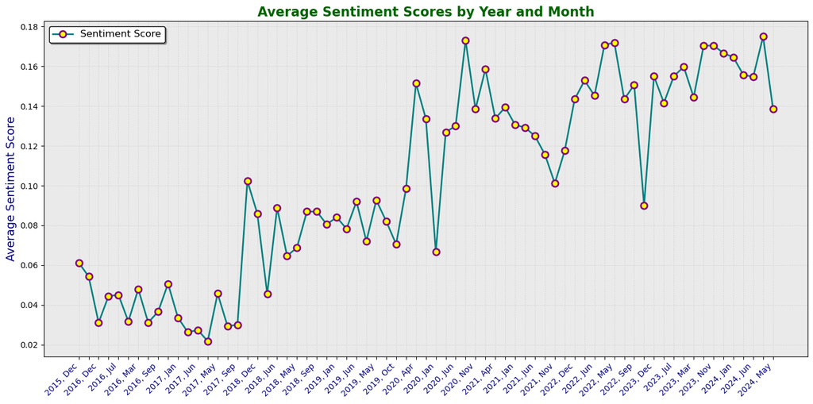

```python
plt.figure(figsize=(14, 7))

# Plot the average sentiment scores with customized line and markers
plt.plot(data_grouped['year_month'], data_grouped['sentiment_score'], marker='o', color='teal', linestyle='-', linewidth=2, markersize=8, markerfacecolor='yellow', markeredgewidth=2, markeredgecolor='purple')
plt.grid(visible=True, linestyle='--', linewidth=0.5, color='lightgray')
ax = plt.gca()
ax.set_facecolor('#eaeaea')
labels = data_grouped['year_month']
ax.set_xticks(range(len(labels)))
new_labels = [label if i % 2 == 0 else '' for i, label in enumerate(labels)]
ax.set_xticklabels(new_labels, rotation=45, ha='right', fontsize=10, color='navy')
plt.ylabel('Average Sentiment Score', fontsize=14, color='navy')
plt.title('Average Sentiment Scores by Year and Month', fontsize=16, color='darkgreen', weight='bold')
plt.legend(['Sentiment Score'], loc='upper left', fontsize=12, frameon=True, shadow=True, facecolor='white', edgecolor='black')
plt.tight_layout()
plt.show()
```

### **Interpretation of the Sentiment Scores**

#### **1. Overview of the Graph**

The graph plots the average sentiment scores derived from the Federal Open Market Committee (FOMC) statements over time, with each point representing a specific month and year. The sentiment score is a numerical representation of the tone in the FOMC statements, where higher scores indicate a more optimistic tone and lower scores suggest a more pessimistic or cautious tone.

#### **3. Potential Limitations of a Rule-Based Approach**

While the rule-based sentiment analysis provided by TextBlob is straightforward and effective in many cases, it does have some limitations:

- **Contextual Nuance**: Rule-based models like TextBlob often struggle with understanding the context in which a word is used. For example, the word "inflation" could have different implications depending on whether it is mentioned as a concern or as being under control. A rule-based approach might not fully capture these nuances.
- **Negations and Modifiers**: While TextBlob can handle simple negations (e.g., "not good"), more complex sentence structures may lead to incorrect sentiment scoring. For instance, "Inflation is not expected to rise significantly" might be scored as negative due to the presence of "inflation" and "not", despite the overall sentiment being neutral or even slightly positive.
- **Lack of Domain-Specific Sentiment**: Financial and economic texts often contain domain-specific language that general sentiment analysis tools may not fully understand. Words that are neutral in general language might carry positive or negative connotations in an economic context, and vice versa.

#### **4. Alternative Approach: Domain-Specific Lexicons**

To enhance the accuracy of sentiment analysis in economic texts, a more specialized approach can be used by employing **Domain-Specific Lexicons** like the Loughran-McDonald Sentiment Word Lists. These lexicons are specifically tailored to financial texts, allowing for a more accurate reflection of the language used in FOMC statements.

**Why are There No Negative Scores?** The method using TextBlob has shown predominantly positive or neutral scores, with very few negative scores. This could be due to the general-purpose nature of TextBlob, which may not fully capture the nuanced pessimistic tones often present in economic and financial discussions. TextBlob might also be biased toward recognizing more common forms of positive sentiment while missing the subtleties of cautious or pessimistic language, which are crucial in FOMC statements.

**How Financial Lexicons Address This:** Using a financial-specific lexicon like Loughran-McDonald allows for a more refined sentiment analysis that includes specific categories like "Negative," "Uncertainty," "Litigious," and "Constraining." These categories help in capturing a broader range of sentiment, including negative and uncertain tones, that might be missed by general sentiment analysis tools. By focusing on terms commonly used in financial contexts, this approach ensures that the analysis better reflects the true sentiment conveyed in economic statements, including any pessimistic outlooks.

## Semanatic Scoring Using Financial-Specific Lexicon

#### **1. Introduction**

In financial contexts, the language used in documents such as Federal Open Market Committee (FOMC) statements, earnings reports, and other financial communications often carries specific connotations that general-purpose sentiment analysis tools may not accurately capture. To address this, we implement a semantic scoring approach using a financial-specific lexicon, which allows for more precise and contextually relevant sentiment analysis.

#### **2. The Need for a Financial-Specific Lexicon**

General sentiment analysis tools like TextBlob or VADER are designed to assess sentiment in a wide range of texts, from product reviews to social media posts. However, financial documents often contain specialized language where words may have different implications than in everyday language. For example, words like "growth" or "risk" may have a more nuanced impact on sentiment in financial texts.

Using a financial-specific lexicon helps in accurately identifying the sentiment conveyed in financial documents by considering the unique language used in the financial industry.

#### **3. The Loughran-McDonald Sentiment Word Lists**

One of the most popular financial-specific lexicons is the **Loughran-McDonald Sentiment Word Lists**. This lexicon was developed specifically for analyzing the tone of financial documents such as earnings calls, annual reports, and other corporate communications. It categorizes words into several sentiment classes, including:

- **Positive**: Words that generally convey optimism, such as "growth," "strong," and "profit."
- **Negative**: Words that suggest pessimism or concern, like "loss," "decline," and "risk."
- **Uncertainty**: Terms that indicate a lack of clarity or predictability, such as "uncertain," "doubt," and "unknown."
- **Litigious**: Words associated with legal proceedings or regulatory scrutiny, such as "lawsuit" and "regulation."
- **Constraining**: Terms that imply limitations or restrictions, such as "restrict," "limit," and "constrain."
- **Superfluous**: Words that suggest excess or redundancy, which might be viewed negatively in a financial context.

These categories help in assigning more contextually appropriate sentiment scores to financial documents.

#### **4. Methodology**

**a. Preprocessing the Text** The first step in semantic scoring is to preprocess the text of the FOMC statements. This involves:

- **Lowercasing**: Converting all text to lowercase to ensure uniformity.
- **Tokenization**: Splitting the text into individual words (tokens).
- **Stopword Removal**: Removing common words that do not contribute to sentiment, like "and," "the," and "is."
- **Lemmatization**: Reducing words to their root form, ensuring that different forms of a word are treated the same (e.g., "running" becomes "run").

**b. Lexicon Matching** After preprocessing, each word in the text is compared against the financial-specific lexicon. For each word found in the lexicon, the corresponding sentiment category (e.g., positive, negative) is identified, and a count is incremented for that category.

**c. Calculating Sentiment Scores** The sentiment score for each document is calculated by summing the counts of words in each sentiment category. This produces a profile of the document's sentiment, showing how many words fall into each category (positive, negative, etc.).

```python
# Initialize the lemmatizer and stopwords
lemmatizer = WordNetLemmatizer()
stop_words = set(stopwords.words('english'))

# Define the preprocessing function
def preprocess_text(text):
    text = text.lower()
    tokens = word_tokenize(text)
    tokens = [word for word in tokens if word.isalnum() and word not in stop_words]
    tokens = [lemmatizer.lemmatize(token) for token in tokens]
    return tokens  # Return tokens for lexicon matching

# Load the Loughran-McDonald Sentiment Word List
lm_sentiment_df = pd.read_csv('Loughran-McDonald_MasterDictionary.csv')

# Convert the DataFrame into a dictionary with sentiment categories as keys
sentiment_lexicon = {
    "Positive": set(lm_sentiment_df[lm_sentiment_df['Positive'] > 0]['Word'].str.lower()),
    "Negative": set(lm_sentiment_df[lm_sentiment_df['Negative'] > 0]['Word'].str.lower()),
    "Uncertainty": set(lm_sentiment_df[lm_sentiment_df['Uncertainty'] > 0]['Word'].str.lower()),
    "Litigious": set(lm_sentiment_df[lm_sentiment_df['Litigious'] > 0]['Word'].str.lower()),
    "Strong_Modal": set(lm_sentiment_df[lm_sentiment_df['Strong_Modal'] > 0]['Word'].str.lower()),
    "Weak_Modal": set(lm_sentiment_df[lm_sentiment_df['Weak_Modal'] > 0]['Word'].str.lower()),
    "Constraining": set(lm_sentiment_df[lm_sentiment_df['Constraining'] > 0]['Word'].str.lower())
}

# Function to calculate and normalize sentiment score
def calculate_normalized_sentiment(tokens, lexicon):
    sentiment_scores = {
        "Positive": 0,
        "Negative": 0,
        "Uncertainty": 0,
        "Litigious": 0,
        "Strong_Modal": 0,
        "Weak_Modal": 0,
        "Constraining": 0
    }

    for token in tokens:
        for category in sentiment_scores:
            if token in lexicon[category]:
                sentiment_scores[category] += 1

    # Raw sentiment score
    raw_score = (sentiment_scores['Positive'] - sentiment_scores['Negative'] - sentiment_scores['Uncertainty'] )

    # Calculate possible max and min scores
    max_score = len(tokens)
    min_score = -max_score  # All tokens are negative

    # Normalize the score to be between -1 and 1
    if max_score != min_score:  # Avoid division by zero
        normalized_score = 2 * ((raw_score - min_score) / (max_score - min_score)) - 1
    else:
        normalized_score = 0  # If the text is empty or has no relevant words

    return normalized_score

# Directory where the CSV files are stored
directory = 'C:/Users/fatem/Downloads/NLP/RATask/statements'

# Process each document and update the DataFrame with sentiment scores
for index, row in data.iterrows():
    sentiment_path = os.path.join(directory, row['sentiment_corp'])
    if os.path.exists(sentiment_path):
        with open(sentiment_path, 'r', encoding='utf-8') as file:
            sentiment_text = file.read()
        processed_sentiment = preprocess_text(sentiment_text)
        if processed_sentiment:
            data.at[index, 'sentiment_score'] = calculate_normalized_sentiment(processed_sentiment, sentiment_lexicon)
        else:
            data.at[index, 'sentiment_score'] = 0  # Assign 0 if sentiment text is empty
    else:
        data.at[index, 'sentiment_score'] = 0  # Assign 0 if sentiment file does not exist
```

```python
data[['file_name','month','sentiment_score']]
```

|  | file_name | month | sentiment_score |
| --- | --- | --- | --- |
| 0 | 2015_1 | Dec | -0.002703 |
| 1 | 2016_1 | Jan | -0.011494 |
| 2 | 2016_2 | Mar | 0.005634 |
| 3 | 2016_3 | Apr | 0.005525 |
| 4 | 2016_4 | Jun | -0.014793 |
| ... | ... | ... | ... |
| 68 | 2024_1 | Jan | -0.013761 |
| 69 | 2024_2 | Mar | -0.014085 |
| 70 | 2024_3 | May | -0.027027 |
| 71 | 2024_4 | Jun | -0.008969 |
| 72 | 2024_5 | Jul | -0.017621 |

73 rows × 3 columns

```python
# Extract the year and shorten the month from the file_name and month columns
data['year'] = data['file_name'].apply(lambda x: x.split('_')[0])
data['month'] = data['month'].apply(lambda x: x[:3])  # Shorten month names to the first three letters
data_grouped = data.groupby(['year', 'month'])['sentiment_score'].mean().reset_index()
data_grouped['year_month'] = data_grouped['year'] + ', ' + data_grouped['month']
```

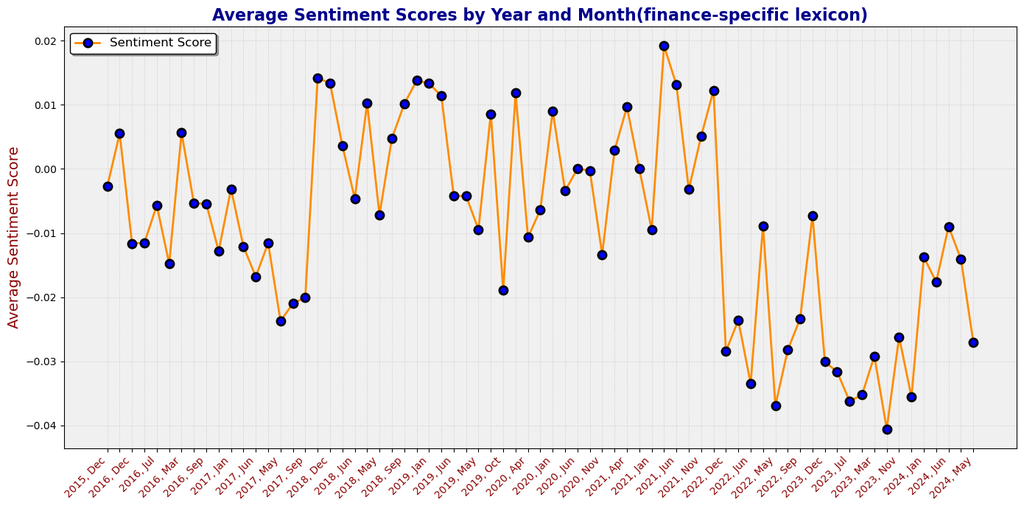

```python
plt.figure(figsize=(14, 7))

# Plot the average sentiment scores with customized line and markers
plt.plot(data_grouped['year_month'], data_grouped['sentiment_score'], marker='o', color='darkorange', linestyle='-', linewidth=2, markersize=8, markerfacecolor='blue', markeredgewidth=2, markeredgecolor='black')
plt.grid(visible=True, linestyle='--', linewidth=0.5, color='lightgray')
ax = plt.gca()
ax.set_facecolor('#f0f0f0')
labels = data_grouped['year_month']
ax.set_xticks(range(len(labels)))
new_labels = [label if i % 2 == 0 else '' for i, label in enumerate(labels)]
ax.set_xticklabels(new_labels, rotation=45, ha='right', fontsize=10, color='darkred')
plt.ylabel('Average Sentiment Score', fontsize=14, color='darkred')
plt.title('Average Sentiment Scores by Year and Month(finance-specific lexicon)', fontsize=16, color='darkblue', weight='bold')
plt.legend(['Sentiment Score'], loc='upper left', fontsize=12, frameon=True, shadow=True, facecolor='white', edgecolor='black')
plt.tight_layout()
plt.show()
```

### **Event-Based Comparison and Interpretation of The Methods**

#### **1.** 2015 to 2016: Post-Great Recession Recovery**

- **General Sentiment Analysis**: Shows relatively stable but positive sentiment, indicating a neutral to optimistic interpretation.
- **Financial-Specific Lexicon**: Captures more fluctuations and occasional negative sentiment, reflecting the FOMC's cautious outlook due to global uncertainties like China's slowdown and Brexit.

#### **3.** 2019: Trade Tensions and Economic Concerns**

- **General Sentiment Analysis**: Some fluctuations but generally positive, perhaps underestimating the impact of trade tensions.
- **Financial-Specific Lexicon**: More pronounced dips, indicating the FOMC's concern about the potential negative impact of U.S.-China trade tensions on the global economy.

#### **5.** 2021 to 2022: Recovery and Inflation Concerns**

- **General Sentiment Analysis**: High sentiment scores, showing strong optimism during recovery.
- **Financial-Specific Lexicon**: Mixed sentiment with noticeable dips, reflecting both the economic recovery and emerging inflation concerns, providing a more nuanced interpretation.

### In Summary

The financial-specific lexicon provides a more accurate and detailed reflection of the FOMC's sentiment, particularly in capturing caution and negative outlooks during periods of economic uncertainty (e.g., trade tensions, the COVID-19 pandemic). In contrast, the general sentiment analysis tends to lean towards a more positive or neutral interpretation, potentially missing critical nuances. The financial-specific approach better aligns with actual economic events, making it a more reliable tool for understanding the FOMC’s outlook.

```python
sentiment_scores_df = data[['file_name', 'month', 'sentiment_score']]
output_file_path = 'C://Users//fatem/Downloads//NLP//RATask//sentement_scores.csv'  # Adjust the path as needed
sentiment_scores_df.to_csv(output_file_path, index=False)

print(f"Sentiment scores have been saved to {output_file_path}")
```

```
Sentiment scores have been saved to C://Users//fatem/Downloads//NLP//RATask/sentement_scores.csv
```

## Further Evaluation of the Sentiment Analysis Method

To further evaluate the effectiveness of this sentiment analysis method, it would be beneficial to correlate the sentiment scores with key economic indicators such as employment rates, GDP growth, and inflation rates over the same period:

- **Employment**: By analyzing the trends in employment rates alongside sentiment scores, we could assess whether positive or negative sentiment in FOMC statements correlates with actual changes in job creation or unemployment levels.
- **GDP Growth**: Comparing sentiment scores with GDP growth figures could help determine if optimistic language in the FOMC statements is aligned with periods of economic expansion, and whether cautious or negative language corresponds with economic slowdowns.
- **Inflation**: Given the central role of the FOMC in managing inflation, observing how sentiment scores align with inflation trends could offer insights into how effectively the sentiment analysis reflects the FOMC’s concerns about rising prices and their actions to control inflation.

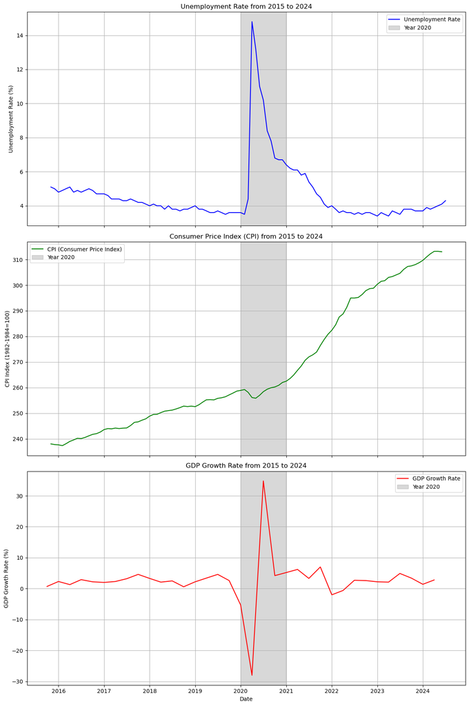

```python
path = 'C:/Users/fatem/Downloads/NLP/RATask/'
# Load the CSV data for all indicators
unemployment_data = pd.read_csv(path + 'unemployment.csv')
inflation_data = pd.read_csv(path + 'inflation.csv')
growth_data = pd.read_csv(path + 'growth.csv')

# Convert the 'DATE' column to datetime format
unemployment_data['DATE'] = pd.to_datetime(unemployment_data['DATE'])
inflation_data['DATE'] = pd.to_datetime(inflation_data['DATE'])
growth_data['DATE'] = pd.to_datetime(growth_data['DATE'])


fig, axs = plt.subplots(3, 1, figsize=(12, 18), sharex=True)

# Plot Unemployment Rate
axs[0].plot(unemployment_data['DATE'], unemployment_data['UNRATE'], label='Unemployment Rate', color='blue')
axs[0].axvspan('2020-01-01', '2020-12-31', color='gray', alpha=0.3, label='Year 2020')
axs[0].set_ylabel('Unemployment Rate (%)')
axs[0].set_title('Unemployment Rate from 2015 to 2024')
axs[0].legend()
axs[0].grid(True)

# Plot Inflation (CPI)
axs[1].plot(inflation_data['DATE'], inflation_data['CPIAUCSL'], label='CPI (Consumer Price Index)', color='green')
axs[1].axvspan('2020-01-01', '2020-12-31', color='gray', alpha=0.3, label='Year 2020')
axs[1].set_ylabel('CPI Index (1982-1984=100)')
axs[1].set_title('Consumer Price Index (CPI) from 2015 to 2024')
axs[1].legend()
axs[1].grid(True)

# Plot GDP Growth
axs[2].plot(growth_data['DATE'], growth_data['GDP'], label='GDP Growth Rate', color='red')
axs[2].axvspan('2020-01-01', '2020-12-31', color='gray', alpha=0.3, label='Year 2020')
axs[2].set_ylabel('GDP Growth Rate (%)')
axs[2].set_title('GDP Growth Rate from 2015 to 2024')
axs[2].legend()
axs[2].grid(True)


axs[2].set_xlabel('Date')
plt.tight_layout()
plt.show()
```

### Interpretation of Sentiment Scores Compared with Economic Indicators

#### **Key Insights:**

# Policy Stance Scoring by Topic Modeling

## Methodology

### **Rationale for Using LDA and Topic Modeling**

Analyzing Federal Open Market Committee (FOMC) statements or other financial documents requires an understanding of the underlying themes, particularly in terms of economic policy direction—whether they are expansionary or contractionary. Manually identifying these themes can be both time-consuming and subjective. In this context, **Latent Dirichlet Allocation (LDA)**, a widely-used topic modeling technique, provides a systematic and objective approach.

**Topic Modeling through LDA facilitates the automatic discovery of abstract "topics" within a collection of documents. Applied to FOMC statements, these topics may correspond to themes such as "interest rate adjustments," "inflation management," "labor market conditions," or "quantitative easing," which can then be analyzed to infer the policy direction—whether it leans towards expansionary or contractionary measures.**

#### **Functionality of LDA**

**Latent Dirichlet Allocation (LDA)** is a generative probabilistic model that posits each document (e.g., a policy text) as a mixture of several topics, where each topic is represented by a distribution over words. The following steps outline how LDA functions:

1. **Document-Topic Distribution**: LDA assumes that each document within a corpus is composed of a mix of topics. For example, a single FOMC statement may address topics related to inflation, unemployment, and monetary policy.
2. **Topic-Word Distribution**: Each topic is defined by a distribution over words. For instance, a topic related to inflation might frequently include terms like "inflation," "prices," "costs," and "increase."
3. **Inference Process**: LDA operates by inferring topics and their distribution across documents from the given text data. It assigns probabilities to the likelihood that a specific word within a document is associated with a particular topic.
4. **Topic Assignment**: After modeling the topics, LDA assigns a topic distribution to each document. For instance, an FOMC statement might be found to be 60% focused on inflation and 40% on employment.
5. **Interpretation**: The discovered topics are then interpreted. By analyzing the words most closely associated with each topic, one can label these topics and comprehend the overarching themes within the policy texts. For instance, a topic dominated by words such as "stimulus," "support," and "growth" may be interpreted as reflecting an expansionary policy stance. Conversely, a topic featuring words like "hike," "restrict," and "control" might suggest a contractionary policy approach.

#### **Application for Scoring Policy Texts**

In addition to selecting appropriate parameters for the LDA model and the interpretation of topics, a crucial step in the preprocessing of the textual data involved refining the word frequencies. This was done to ensure that the model's results were both meaningful and unbiased. Specifically, words that fell above the 78th percentile or below the 5th percentile in frequency were removed before running the LDA. Here's why this step was necessary:

#### 1. **Removal of High-Frequency Words (Above 78th Percentile)**

- **Rationale**: High-frequency words often include common terms that may not carry significant information related to specific topics. These words, such as "the," "is," "and," etc., are often referred to as stop words. Although domain-specific stop words (like "Federal," "Reserve," etc.) might not be typically considered stop words, their high frequency across documents could disproportionately influence the model, leading to skewed or less meaningful topic distributions. By removing these high-frequency words, the model is better able to focus on the more content-specific words that define each topic, leading to a clearer differentiation between expansionary and contractionary policies.

#### 2. **Removal of Low-Frequency Words (Below 5th Percentile)**

- **Rationale**: Words that appear very infrequently (below the 5th percentile) may not be representative of broader trends within the text. These low-frequency words could introduce noise into the model, as their rarity might cause them to disproportionately influence the topic assignment, despite not being relevant to the overall policy stance. By removing these low-frequency words, we avoid the risk of overfitting the model to idiosyncratic terms that do not generalize well across the dataset.

#### 3. **Impact on LDA Model**

- **Balanced Topic Representation**: By filtering out both extremely common and extremely rare words, the LDA model is less likely to be skewed by outliers in word frequency. This ensures that the topics identified by the model are more robust and that the bigrams within each topic are truly indicative of the policy stance.
- **Improved Interpretability**: The resulting topics are more interpretable because they are based on words that occur with a frequency that reflects their actual importance in the context of FOMC statements. This makes it easier to assign the topics to either contractionary or expansionary policies and to generate meaningful policy stance scores.

### **Normalization of LDA Scores Between -1 and 1**

To quantify the stance of each document, the LDA model assigns a score based on the topics discovered in the text. These raw scores, however, may not be directly comparable across different documents due to variations in the number of words or the inherent distribution of topics.

**Normalization** is applied to make these scores interpretable on a common scale, specifically between -1 and 1, where:

- **-1** indicates a strongly contractionary stance.
- **0** suggests a neutral stance.
- **1** indicates a strongly expansionary stance.

The normalization process involves:

   $\text{Normalized Score} = \frac{2 \times (\text{Raw Score} - \text{Min Score})}{\text{Max Score} - \text{Min Score}} - 1$

```python
# Initialize the lemmatizer and stopwords
lemmatizer = WordNetLemmatizer()
stop_words = set(stopwords.words('english'))

# Custom stop words to remove frequent non-informative words
custom_stop_words = set([
    "part", "related", "found", "also", "one", "allow", "required", "approach",
    "approve", "made", "direct", "primary", "domestic", "reflect", "credit",
    "execute", "stance", "offering", "increase"
])

# List of month names to remove
months = [
    "january", "february", "march", "april", "may", "june",
    "july", "august", "september", "october", "november", "december"
]

# Updated preprocessing function to remove all numbers, month names, and custom stop words
def preprocess_text(text):
    text = text.lower()
    # Remove all numbers
    text = re.sub(r'\d+', '', text)
    # Remove month names
    for month in months:
        text = text.replace(month, '')
    tokens = word_tokenize(text)
    tokens = [word for word in tokens if word.isalnum() and word not in stop_words and word not in custom_stop_words]
    tokens = [lemmatizer.lemmatize(token) for token in tokens]
    processed_text = ' '.join(tokens)
    return processed_text

# Load the ODS file
file_path = 'C:/Users/fatem/Downloads/NLP/RATask/data.ods'
policy_data = pd.read_excel(file_path, engine='odf')

# Populate the sentiment and policy columns with the corresponding file paths
policy_data['policy_corp'] = policy_data['file_name'] + '_policy.csv'

# Directory where the CSV files are stored
directory = 'C:/Users/fatem/Downloads/NLP/RATask/statements'

# Process each document and store the processed text
policy_texts = []
policy_indices = []

for index, row in policy_data.iterrows():
    policy_path = os.path.join(directory, row['policy_corp'])
    if os.path.exists(policy_path):
        with open(policy_path, 'r', encoding='utf-8') as file:
            policy_text = file.read()
        processed_policy = preprocess_text(policy_text)
        if processed_policy:
            policy_texts.append(processed_policy)
            policy_indices.append(index)
    else:
        policy_data.at[index, 'policy_score'] = 0  # Assign 0 if the policy file does not exist

# Proceed if there are valid policy texts
if policy_texts:

    # Create a CountVectorizer with only bigrams (or trigrams)
    vectorizer = CountVectorizer(ngram_range=(1, 2))
    X = vectorizer.fit_transform(policy_texts)

    word_freq = X.sum(axis=0).A1
    vocab = vectorizer.get_feature_names_out()

    # Calculate word frequencies
    word_freq_dict = dict(zip(vocab, word_freq))
    sorted_word_freq = sorted(word_freq_dict.items(), key=lambda item: item[1])

    # Determine the 10th and 80th percentiles
    lower_bound = int(len(sorted_word_freq) * 0.05)
    upper_bound = int(len(sorted_word_freq) * 0.78)

    # Filter out the words outside the 10th to 80th percentile range
    filtered_vocab = [word for word, freq in sorted_word_freq[lower_bound:upper_bound]]
    filtered_vectorizer = CountVectorizer(vocabulary=filtered_vocab)
    filtered_X = filtered_vectorizer.fit_transform(policy_texts)

    # Apply LDA
    n_topics = 3  # users are encouraged to change this number
    lda = LatentDirichletAllocation(n_components=n_topics, random_state=42)
    lda.fit(filtered_X)

    # Display the topics with the top words in a table
    def display_topics(model, feature_names, no_top_words):
        topic_words = []
        for topic_idx, topic in enumerate(model.components_):
            words = [feature_names[i] for i in topic.argsort()[:-no_top_words - 1:-1]]
            topic_words.append(words)

        topic_df = pd.DataFrame(topic_words).T
        topic_df.columns = [f"Topic {i + 1}" for i in range(n_topics)]
        print(f"\nTop {no_top_words} bigrams for each topic:")
        print(topic_df)

    no_top_words = 30
    display_topics(lda, filtered_vectorizer.get_feature_names_out(), no_top_words)

    # Get the topic distribution for each document
    doc_topic_dist = lda.transform(filtered_X)

    # Assign scores to topics: 1 for Topic 2 (expansionary), -1 for Topic 1 (contractionary)
    topic_scores = np.array([-1, 1, -1])

    # Calculate the policy stance score for each document
    policy_scores = doc_topic_dist.dot(topic_scores)

    # Normalize the policy scores to be between -1 and 1
    min_score = policy_scores.min()
    max_score = policy_scores.max()
    normalized_policy_scores = 2 * (policy_scores - min_score) / (max_score - min_score) - 1

    # Save the scores into the DataFrame
    for idx, score in zip(policy_indices, normalized_policy_scores):
        policy_data.at[idx, 'policy_score'] = score

    # Select the required columns for the output
    policy_scores_df = policy_data[['file_name', 'month', 'policy_score']]

    # Specify the output file path
    output_file_path = 'C://Users//fatem/Downloads//NLP//RATask//policy_scores.csv'  # Adjust the path as needed

    # Save the DataFrame to a CSV file
    policy_scores_df.to_csv(output_file_path, index=False)

    print(f"Policy stance scores have been saved to {output_file_path}")

else:
    print("No valid policy texts were found to process.")
```

```
Top 30 bigrams for each topic:
          Topic 1        Topic 2      Topic 3
0          excess       purchase      monthly
1        maturity    functioning    aggregate
2         trading         smooth      minimum
3         holiday         needed          bid
4     accommodate            cmb     reinvest
5         similar          chair     standing
6       available      increased       needed
7      convention    temporarily       stated
8           value     discretion       modest
9         weekend        release       reason
10           held        sustain    deviation
11       outright        support     maturing
12        limited      authorize     received
```

[output cut: 18 more lines]

#### Calculation of Policy Stance Scores

To quantify the overall policy stance of each FOMC statement, a scoring system was implemented. The score is calculated based on the weighted probabilities of each topic within a given statement:

$\text{Score} = -1 \times (\text{Topic 1 Probability}) + 1 \times (\text{Topic 2 Probability}) - 1 \times (\text{Topic 3 Probability})$

This formula reflects the idea that:

- **Topic 1 and Topic 3** are associated with contractionary policies, so their contributions to the score are negative.
- **Topic 2** is associated with expansionary policies, so its contribution is positive.

The score is then normalized to ensure it falls within the range of -1 to 1, where:

- **-1** indicates a strongly contractionary stance,
- **1** indicates a strongly expansionary stance,
- **0** indicates a neutral or balanced stance.

```python
# Extract the year and shorten the month from the file_name and month columns
policy_scores_df.loc[:, 'year'] = policy_scores_df['file_name'].apply(lambda x: x.split('_')[0])
policy_scores_df.loc[:, 'month'] = policy_scores_df['month'].apply(lambda x: x[:3])  # Shorten month names to the first three letters

# Group by year and month, and calculate the average policy score
policy_scores_df_grouped = policy_scores_df.groupby(['year', 'month'])['policy_score'].mean().reset_index()

# Combine year and month into a single label for the x-axis
policy_scores_df_grouped['year_month'] = policy_scores_df_grouped['year'] + ', ' + policy_scores_df_grouped['month']
```

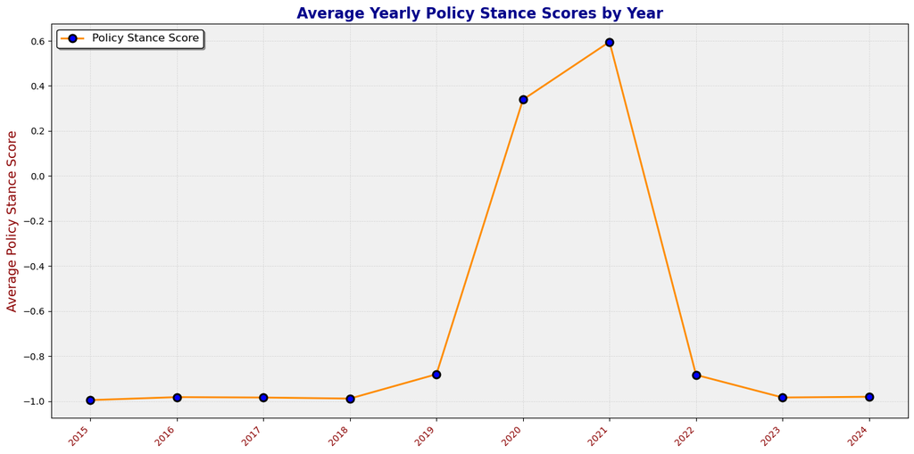

```python
# Group by year and calculate the average policy score
policy_scores_df_grouped_yearly = policy_scores_df.groupby(['year'])['policy_score'].mean().reset_index()

# Plot the average yearly policy stance scores
plt.figure(figsize=(14, 7))
plt.plot(policy_scores_df_grouped_yearly['year'], policy_scores_df_grouped_yearly['policy_score'], marker='o', color='darkorange', linestyle='-', linewidth=2, markersize=8, markerfacecolor='blue', markeredgewidth=2, markeredgecolor='black')
plt.grid(visible=True, linestyle='--', linewidth=0.5, color='lightgray')
ax = plt.gca()
ax.set_facecolor('#f0f0f0')
ax.set_xticks(range(len(policy_scores_df_grouped_yearly['year'])))
ax.set_xticklabels(policy_scores_df_grouped_yearly['year'], rotation=45, ha='right', fontsize=10, color='darkred')
plt.ylabel('Average Policy Stance Score', fontsize=14, color='darkred')
plt.title('Average Yearly Policy Stance Scores by Year', fontsize=16, color='darkblue', weight='bold')
plt.legend(['Policy Stance Score'], loc='upper left', fontsize=12, frameon=True, shadow=True, facecolor='white', edgecolor='black')
plt.tight_layout()
plt.show()
```

### Analysis of Policy Stance in the USA Based on LDA Model and Historical Context

The graph above, generated from Latent Dirichlet Allocation (LDA) topic modeling of Federal Open Market Committee (FOMC) statements, illustrates the evolution of the U.S. monetary policy stance from 2015 to 2024. Each point on the graph represents the average policy stance score for a given year, normalized between -1 and 1, where -1 indicates a strongly contractionary stance, and 1 indicates a strongly expansionary stance.

#### Periods of Policy Stance and Their Historical Context

1. **2015-2019: Gradual Tightening (Contractionary Policy)**
   - **Duration**: This period marks the aftermath of the Great Recession, during which the Federal Reserve gradually transitioned from an expansionary stance to a more contractionary policy. The Fed began to raise interest rates from historically low levels, reflecting improved economic conditions and concerns over potential inflation.
   - **Initiating Events**: The recovery of the U.S. economy, falling unemployment rates, and the need to normalize monetary policy after years of quantitative easing.
   - **Policy Strictness**: This period was characterized by cautious tightening, with the Fed gradually increasing interest rates to avoid derailing the economic recovery.
2. **2020-2021: Emergency Expansion (Expansionary Policy)**
   - **Duration**: The most dramatic shift in the policy stance occurred in 2020-2021, as the COVID-19 pandemic struck the global economy. The Fed responded with aggressive expansionary policies, including slashing interest rates to near zero and implementing large-scale asset purchases.
   - **Initiating Events**: The global pandemic led to a sharp economic downturn, necessitating emergency measures to stabilize financial markets and support economic activity.
   - **Policy Strictness**: The expansionary measures during this period were unprecedented in scale, aimed at preventing a deep and prolonged recession.
3. **2022-2024: Aggressive Tightening (Contractionary Policy)**
   - **Duration**: Starting in late 2021 and continuing through 2024, the Fed shifted back to a contractionary stance in response to surging inflation, which reached multi-decade highs. This period is marked by rapid interest rate hikes and the reduction of the Fed's balance sheet through quantitative tightening.
   - **Initiating Events**: Persistent inflation, driven by supply chain disruptions, labor shortages, and high consumer demand post-pandemic, triggered this aggressive tightening.
   - **Policy Strictness**: The contractionary policies during this period were notably harsher compared to the 2015-2019 period, as the Fed acted decisively to control inflation.

#### Comparison of Policy Strictness Across Periods

- **2015-2019 vs. 2022-2024**: Both periods were contractionary, but the strictness of the policy stance is markedly different. The gradual tightening from 2015 to 2019 was moderate and cautious, designed to avoid jeopardizing the economic recovery. In contrast, the post-2021 tightening was much more aggressive, with rapid interest rate hikes reflecting the urgency of addressing high inflation.
- **2020-2021 Expansion vs. Other Periods**: The expansionary stance during 2020-2021 was the most aggressive in recent history, driven by the unique challenges of the pandemic. The scale and speed of the measures taken were far greater than any expansionary actions during previous economic downturns.

#### Compatibility and Sensibility of the LDA Model Results

The LDA model, by categorizing the language of FOMC statements into distinct topics, successfully captures the overall shifts in the Federal Reserve's policy stance over the years. The model's results, as depicted in the graph, align well with the historical narrative:

#### Areas for Improvement in the Model

While the LDA model provides a valuable overview of policy stance changes, there are some limitations to consider:

1. **Nuanced Detection of Policy Strictness**:
   - The model may not fully capture the varying degrees of strictness within contractionary or expansionary periods. For example, the harsher contractionary stance from 2022 onwards compared to 2015-2019 may not be as distinctly represented due to the similar language used across both periods.
   - To address this, a more granular model could incorporate additional context or data, such as economic indicators, to better differentiate the intensity of policy measures.
2. **Impact of Seemingly Neutral Language**:
   - FOMC statements often contain neutral or cautious language that may not fully convey the strictness of policy actions. This could lead to some periods appearing less differentiated in the model than they are in practice.
   - Incorporating sentiment analysis or advanced linguistic features might help in capturing subtle shifts in tone that correlate with policy strictness.
3. **Data Availability**:
   - The model's effectiveness is partly constrained by the data it analyzes. If FOMC statements lack explicit language reflecting the severity of policy changes, the model may underrepresent these shifts.
   - Expanding the dataset to include minutes of FOMC meetings or speeches by Federal Reserve officials could provide a richer source of information for analysis.

### Conclusion

The LDA model provides a coherent and sensible framework for analyzing the evolution of U.S. monetary policy stance over time. While the model successfully captures major policy shifts, further refinements could enhance its ability to detect nuanced differences in policy strictness, especially during periods of aggressive tightening or expansion. Incorporating additional data sources and advanced linguistic techniques could improve the model's accuracy and depth, making it a more powerful tool for understanding the Federal Reserve's approach to monetary policy.